# TFIDFguide

Ted

2018年7月23日

### Analyzing word and document frequency: tf-idf

The statistic tf-idf is intended to measure how important a word is to a document in a collection (or corpus) of documents

1. term frequency (tf), how frequently a word occurs in a document
2. inverse document frequency (idf): decreases the weight for commonly used words and increases the weight for words that are not used very much in a collection of documents.

   $$idf(\text{term}) = \ln{\left(\frac{n_{\text{documents}}}{n_{\text{documents containing term}}}\right)}$$

### Term frequency in Jane Austen’s novels

```r
library(dplyr)
library(janeaustenr)
library(tidytext)

book_words <- austen_books() %>%
  unnest_tokens(word, text) %>%
  count(book, word, sort = TRUE) %>%
  ungroup()

total_words <- book_words %>%
  group_by(book) %>%
  summarize(total = sum(n))

book_words <- left_join(book_words, total_words)
```

```r
book_words
```

```
## # A tibble: 40,379 x 4
##    book              word      n  total
##    <fct>             <chr> <int>  <int>
##  1 Mansfield Park    the    6206 160460
##  2 Mansfield Park    to     5475 160460
##  3 Mansfield Park    and    5438 160460
##  4 Emma              to     5239 160996
##  5 Emma              the    5201 160996
##  6 Emma              and    4896 160996
##  7 Mansfield Park    of     4778 160460
##  8 Pride & Prejudice the    4331 122204
##  9 Emma              of     4291 160996
## 10 Pride & Prejudice to     4162 122204
## # ... with 40,369 more rows
```

`n`:the number of times that word is used in that book `total`: the total words in that book

term frequency: look at the distribution of n/total for each novel

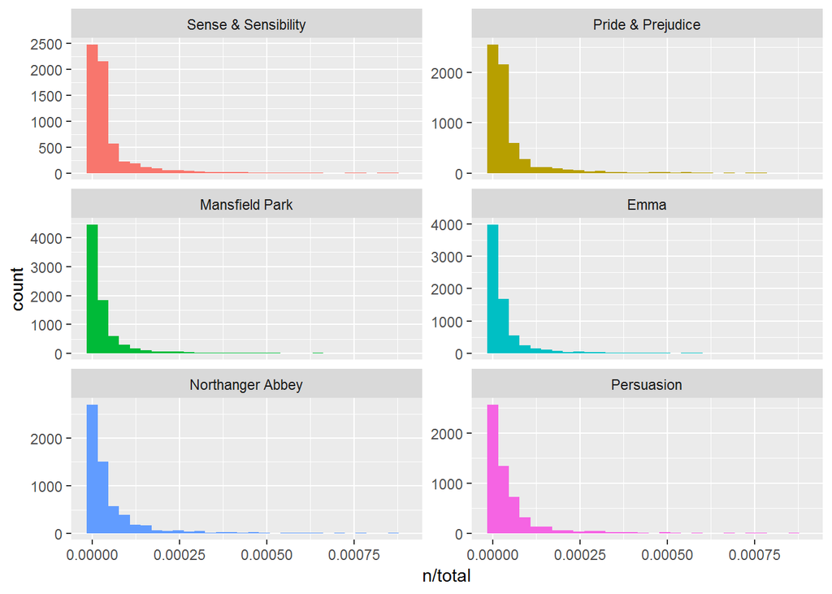

```r
library(ggplot2)

ggplot(book_words, aes(n/total, fill = book)) +
  geom_histogram(show.legend = FALSE) +
  xlim(NA, 0.0009) +
  facet_wrap(~book, ncol = 2, scales = "free_y")
```

**Zipf’s law** states that the frequency that a word appears is inversely proportional to its rank.

```r
freq_by_rank <- book_words %>%
  group_by(book) %>%
  mutate(rank = row_number(),
         `term frequency` = n/total)

head(freq_by_rank)
```

```
## # A tibble: 6 x 6
## # Groups:   book [2]
##   book           word      n  total  rank `term frequency`
##   <fct>          <chr> <int>  <int> <int>            <dbl>
## 1 Mansfield Park the    6206 160460     1           0.0387
## 2 Mansfield Park to     5475 160460     2           0.0341
## 3 Mansfield Park and    5438 160460     3           0.0339
## 4 Emma           to     5239 160996     1           0.0325
## 5 Emma           the    5201 160996     2           0.0323
## 6 Emma           and    4896 160996     3           0.0304
```

The `rank`column here tells us the rank of each word within the frequency table

### The bind_tf_idf function

bind_tf_idf function (tidytext package) takes a tidy text dataset as input with 1. one row per token (term), per document. 2. One column (`word` here) contains the terms/tokens, 3. one column contains the documents (`book` in this case), 4. column contains the counts, how many times each document contains each term (`n`in this example).

```r
book_words <- book_words %>%
  bind_tf_idf(word, book, n)
book_words
```

```
## # A tibble: 40,379 x 7
##    book              word      n  total     tf   idf tf_idf
##    <fct>             <chr> <int>  <int>  <dbl> <dbl>  <dbl>
##  1 Mansfield Park    the    6206 160460 0.0387     0      0
##  2 Mansfield Park    to     5475 160460 0.0341     0      0
##  3 Mansfield Park    and    5438 160460 0.0339     0      0
##  4 Emma              to     5239 160996 0.0325     0      0
##  5 Emma              the    5201 160996 0.0323     0      0
##  6 Emma              and    4896 160996 0.0304     0      0
##  7 Mansfield Park    of     4778 160460 0.0298     0      0
##  8 Pride & Prejudice the    4331 122204 0.0354     0      0
##  9 Emma              of     4291 160996 0.0267     0      0
## 10 Pride & Prejudice to     4162 122204 0.0341     0      0
## # ... with 40,369 more rows
```

```r
# high tf-idf in Jane Austen’s works
book_words %>%
  select(-total) %>%
  arrange(desc(tf_idf))
```

```
## # A tibble: 40,379 x 6
##    book                word          n      tf   idf  tf_idf
##    <fct>               <chr>     <int>   <dbl> <dbl>   <dbl>
##  1 Sense & Sensibility elinor      623 0.00519  1.79 0.00931
##  2 Sense & Sensibility marianne    492 0.00410  1.79 0.00735
##  3 Mansfield Park      crawford    493 0.00307  1.79 0.00551
##  4 Pride & Prejudice   darcy       373 0.00305  1.79 0.00547
##  5 Persuasion          elliot      254 0.00304  1.79 0.00544
##  6 Emma                emma        786 0.00488  1.10 0.00536
##  7 Northanger Abbey    tilney      196 0.00252  1.79 0.00452
##  8 Emma                weston      389 0.00242  1.79 0.00433
##  9 Pride & Prejudice   bennet      294 0.00241  1.79 0.00431
## 10 Persuasion          wentworth   191 0.00228  1.79 0.00409
## # ... with 40,369 more rows
```

visualization for these high tf-idf words

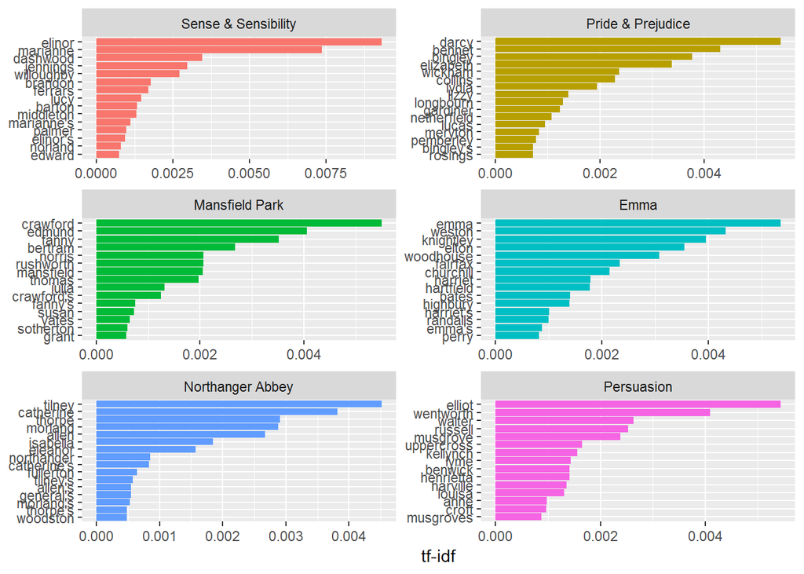

```r
book_words %>%
  arrange(desc(tf_idf)) %>%
  mutate(word = factor(word, levels = rev(unique(word)))) %>%
  group_by(book) %>%
  top_n(15) %>%
  ungroup %>%
  ggplot(aes(word, tf_idf, fill = book)) +
  geom_col(show.legend = FALSE) +
  labs(x = NULL, y = "tf-idf") +
  facet_wrap(~book, ncol = 2, scales = "free") +
  coord_flip()
```

### A corpus of physics texts

1. load text
2. Use `unnest_tokens()` and `count()` to find out how many times each word was used in each text.
3. Clean up the text
4. Calculate tf-idf, then visualize the high tf-idf words

```r
library(gutenbergr)
physics <- gutenberg_download(c(37729, 14725, 13476, 5001), meta_fields = "author")
```

```r
physics_words <- physics %>%
  unnest_tokens(word, text) %>%
  count(author, word, sort = TRUE) %>%
  ungroup()

head(physics_words)
```

```
## # A tibble: 6 x 3
##   author              word      n
##   <chr>               <chr> <int>
## 1 Galilei, Galileo    the    3760
## 2 Tesla, Nikola       the    3604
## 3 Huygens, Christiaan the    3553
## 4 Einstein, Albert    the    2994
## 5 Galilei, Galileo    of     2049
## 6 Einstein, Albert    of     2030
```

```r
# Notice that we make a custom list of stop words and use anti_join() to remove them
library(stringr)

mystopwords <- data_frame(word = c("eq", "co", "rc","ac", "ak", "bn", "fig", "file", "cg", "cb", "cm"))
physics_words <- anti_join(physics_words, mystopwords, by = "word")
```

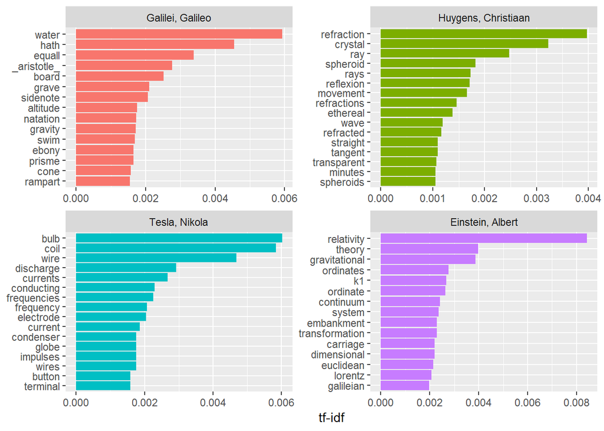

```r
plot_physics <- physics_words %>%
  bind_tf_idf(word, author, n) %>%
  arrange(desc(tf_idf)) %>%
  mutate(word = factor(word, levels = rev(unique(word)))) %>%
  group_by(author) %>%
  top_n(15, tf_idf) %>%
  ungroup %>%
  mutate(author = factor(author, levels = c("Galilei, Galileo","Huygens, Christiaan","Tesla, Nikola","Einstein, Albert")))

ggplot(plot_physics, aes(word, tf_idf, fill = author)) +
  geom_col(show.legend = FALSE) +
  labs(x = NULL, y = "tf-idf") +
  facet_wrap(~author, ncol = 2, scales = "free") +
  coord_flip()
```